# Assignment 2-4: Final report for Module 2

Lucy Hu

March 30, 2020

The New York City Health and Nutrition Examination Survey (NYC HANES) collects data in a population-based, cross-sectional survey to determine health and nutrition status of the New York City population. The dataset contains information on self-reported demographics, health and nutrition questions, and behavioral and drug-use questions as well as laboratory resultd and physical exams.

In this report, we will be using the NYC Hanes dataset to examine what factors are associated with having hypertension and how survey weights impact logistic-regression estimates.

First, looking at factors that are associated with hypertension, I chose to examine age, BMI, and participant’s self-reported general health status.

I created several data displays to better understand how the factors influenced hypertension. In these displays I categorized age into 10-year periods in order to display trends among general age groups.

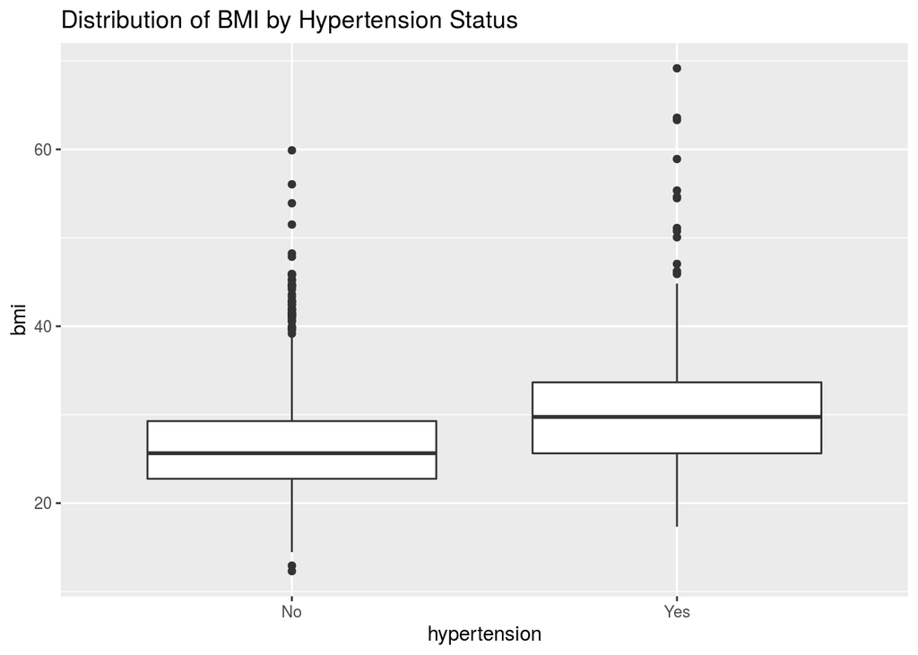

This data display shows that people who are hypertense tend to have higher BMIs.

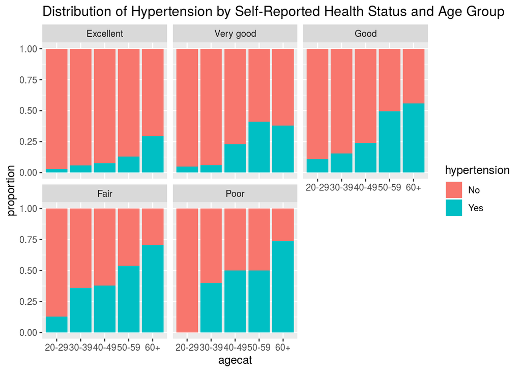

As seen in this second data display, hypertension generally increases with age and reaches higher rates with worse reported health. However, it is noteworthy that those who reported poor health in the age category 20-29 had 0% hypertension. By filtering the dataset, we can see that this is because there were only two participants who reported poor health in this age category and neither had hypertension. However, because there were so few datapoints in this category, it is likely not representative of the entire NYC population.

I then completed a survey-weighted logistic regression. This analysis includes data from both demographic/health questions (which uses the CAPI_WT) as well as physical exam data (uses EXAM_WT). However, because I excluded unavailable data from this analysis, I chose the more exclusive approach and used EXAM_WT.

Fitting generalized (binomial/logit) linear model: hypertension ~ age + bmi + general_health

|  | Estimate | Std. Error | t value | Pr(>\|t\|) |
| --- | --- | --- | --- | --- |
| **(Intercept)** | -6.283 | 0.4812 | -13.06 | 5.914e-37 |
| **age** | 0.05102 | 0.004823 | 10.58 | 2.924e-25 |
| **bmi** | 0.07015 | 0.01206 | 5.819 | 7.267e-09 |
| **general_healthVery good** | 0.6784 | 0.2913 | 2.329 | 0.02001 |
| **general_healthGood** | 0.8533 | 0.2787 | 3.061 | 0.002243 |
| **general_healthFair** | 1.556 | 0.292 | 5.328 | 1.147e-07 |
| **general_healthPoor** | 1.535 | 0.394 | 3.897 | 0.0001018 |

Age was found to have a significant effect on hypertension. Holding all other variables constant, a 1-year increase in age led to 1.05 times the odds of hypertension.

BMI was also found to have a significant relationship. Holding all other variables constant, a 1-unit increase in BMI led to 1.07 times the odds of hypertension.

Participant’s self-reported general health status was also found to have a significant relationship. Holding all other variables constant, reporting poor or fair health in comparison to excellent health had the most significant relationship, with 4.64 and 4.74 times the odds of hypertension respectively. Those who reported good or very good health had 2.35 and 1.97 times the odds of hypertension respectively, both as compared to participants who reported excellent health.

I chose this model with these variables after trying a number of combinations (e.g. including diet, education, marital status) and ultimately eliminated them because they were not significant.

Now to compare, the non-weighted logistic regression presents the following:

Fitting generalized (binomial/logit) linear model: hypertension ~ age + bmi + general_health

|  | Estimate | Std. Error | z value | Pr(>\|z\|) |
| --- | --- | --- | --- | --- |
| **(Intercept)** | -6.608 | 0.4408 | -14.99 | 8.353e-51 |
| **age** | 0.05254 | 0.004281 | 12.27 | 1.272e-34 |
| **bmi** | 0.07291 | 0.01067 | 6.831 | 8.44e-12 |
| **general_healthVery good** | 0.7348 | 0.2692 | 2.73 | 0.006342 |
| **general_healthGood** | 1.146 | 0.2573 | 4.454 | 8.424e-06 |
| **general_healthFair** | 1.66 | 0.2726 | 6.089 | 1.133e-09 |
| **general_healthPoor** | 1.68 | 0.3739 | 4.493 | 7.023e-06 |

I then utilized a data display to help compare the estimates from the weighted and unweighted logistic regressions:

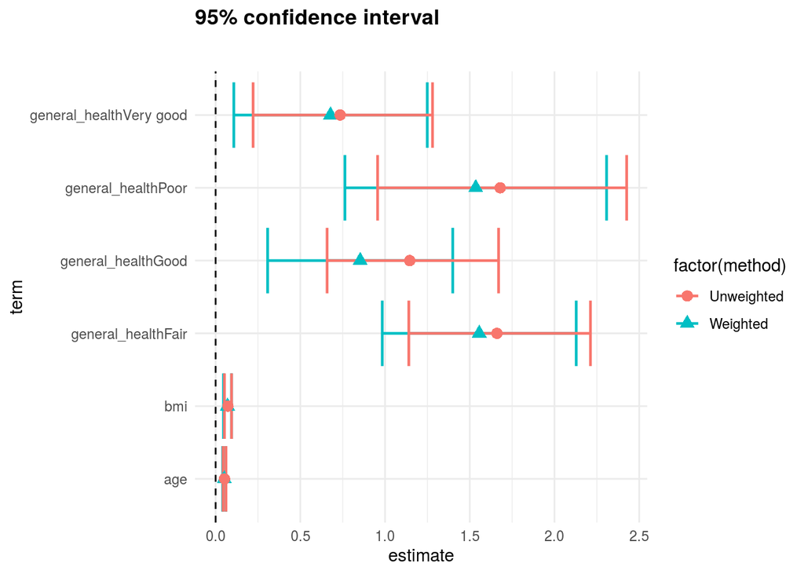

Looking at the data display, the confidence intervals for the unweighted logistic regression estimates skewed higher than those for the weighted value for self-reported general health status. For BMI and age, the confidence intervals appear to overlap.

Overall, the weighted and unweighted logistic regression values seem to be comparable considering the great overlap in confidence intervals.